# Day 3: Key Findings from the Austrian Vegetation DataTag 3: Wichtigste Ergebnisse aus den österreichischen Vegetationsdaten

## DiscussionDiskussion

# 5. Habitat Vulnerability: Where Invasions Concentrate5. Habitat-Verwundbarkeit: Wo sich Invasionen konzentrieren

## Alien Species Share by HabitatAlien-Artenanteil nach Habitat

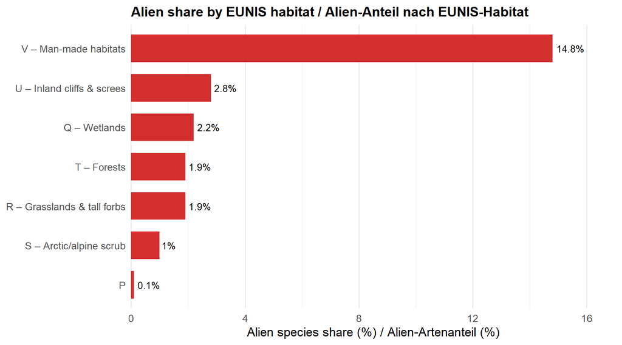

## Accumulation Curves by HabitatAkkumulationskurven nach Habitat

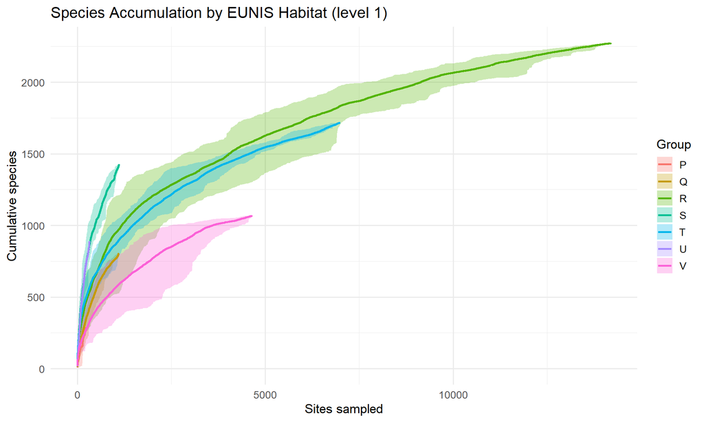

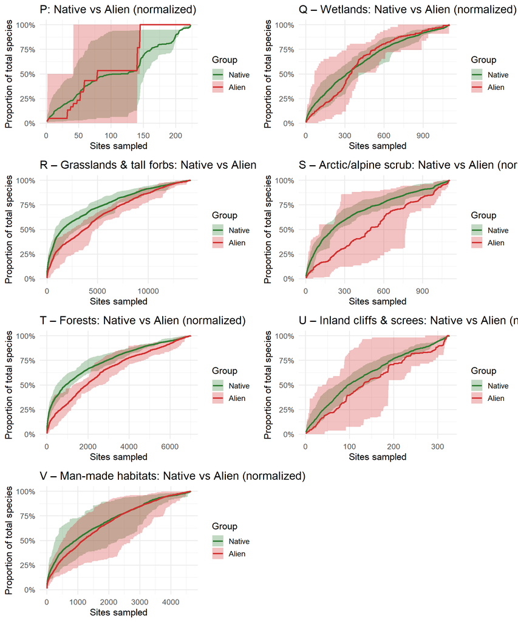

## Estimated Richness by Habitat (SAC-based)Geschätzter Artenreichtum nach Habitat (SAC-basiert)

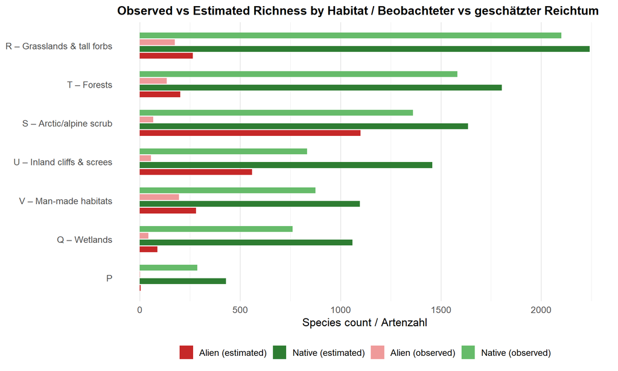

## DiscussionDiskussion

**Invasion varies hugely between habitats.**

The bar chart makes this clear: some habitats have alien proportions above 10%, others are almost alien-free. This is not random.

**Most invaded habitats** share three traits:

- **Frequent disturbance** (ploughing, mowing, flooding) creates open niches. Repeated disturbance prevents native competitive exclusion.
- **High nutrient availability.** Fertilised grasslands, floodplains, roadside verges get regular resource pulses that favour alien establishment (Davis et al. 2000).
- **Human connectivity.** Railway embankments, highway margins, and canal banks receive a steady supply of alien propagules.

Chytry et al. (2008) showed that European habitats differ 100-fold in invasion susceptibility. Our data confirms this for Austria: **habitat type matters more than climate, geography, or propagule pressure**.

**Within-habitat accumulation curves:**

In heavily invaded habitats, the alien curve approaches the native curve (aliens have spread broadly). In lightly invaded habitats, the alien curve is steeper and erratic (a few occurrences at a few sites, typical of early-stage invasion).

**Management priorities:**

1. **High:** Most invaded habitats, where aliens are already abundant. Early action prevents further establishment.
2. **Medium:** Transition habitats where aliens are present but not yet dominant.
3. **Lower:** Alpine and oligotrophic habitats resist invasion for now, but climate change may weaken that resistance.

**Invasion ist nicht gleichmäßig über Habitate verteilt.**

Die EUNIS-Habitat-Analyse zeigt, dass die Invasion durch Alien-Arten sehr heterogen ist. Einige Habitate zeigen Alien-Anteile über 10%, während andere praktisch alien-frei bleiben. Diese Heterogenität folgt klaren ökologischen Regeln.

**Welche Habitate sind am stärksten invadiert und warum?**

Die am stärksten invadierten Habitate in Österreich teilen mehrere Merkmale:

- **Hohe Störungsfrequenz.** Regelmäßig physisch gestörte Habitate (Pflügen, Mähen, Trampeln, Überflutung) schaffen offene Nischen für Alien-Besiedelung.
- **Hohe Ressourcenverfügbarkeit.** Nährstoffreiche Habitate (gedüngte Grasländer, Flussauen mit Sedimentablagerung) liefern die Ressourcen für schnelle Alien-Etablierung. Die Hypothese der schwankenden Ressourcen (Davis et al. 2000) sagt voraus, dass Invasion während Ressourcenpulsen ihren Höhepunkt erreicht.
- **Starke menschliche Konnektivität.** Habitate entlang von Transportkorridoren erhalten eine kontinuierliche Versorgung mit Alien-Propagules.

**Die 100-fache Variation:**

Chytry et al. (2008) zeigten, dass europäische Habitate sich 100-fach in ihrer Anfälligkeit für Pflanzeninvasionen unterscheiden. Unsere österreichischen Daten bestätigen dies: **Habitattyp ist der primäre Determinant der Invasionsanfälligkeit**, wichtiger als Klima, Geografie oder Propagule Pressure.

**Akkumulationskurvenformen unterscheiden sich:**

- In stark invadierten Habitaten nähert sich die Alien-Kurvenform der heimischen an — Aliens haben sich breit verteilt.
- In schwach invadierten Habitaten ist die Alien-Kurve steiler und unregelmäßiger — das Zeichen einer Frühphasen-Invasion.

**Praktische Anwendung für den Naturschutz:**

1. **Hohe Priorität:** Am stärksten invadierte Habitattypen überwachen und managen.
2. **Mittlere Priorität:** Habitate an der Übergangszone beobachten — die “Invasionsfronten”, wo Management am kosteneffektivsten sein kann.
3. **Niedrigere Priorität:** Alpine und oligotrophe Habitate, die derzeit Invasion widerstehen, langfristig monitoren, besonders angesichts des Klimawandels.

# 6. What Kind of Diversity? Dominance, Partitioning, and Evolutionary Breadth6. Welche Art von Diversität? Dominanz, Partitionierung und evolutionäre Breite

So far we have counted species. But not all species contribute equally: some are common, others are rare; some represent unique evolutionary lineages, others are close relatives of species already present. This section asks three questions that go beyond raw counts:

1. **Are rare or common species driving the accumulation?** (Hill numbers)
2. **Does most of Austria’s diversity come from within-site richness or between-site differences?** (Alpha/beta/gamma partitioning)
3. **Do aliens add evolutionary novelty, or just more of the same?** (Phylogenetic diversity)

Bisher haben wir Arten gezählt. Aber nicht alle Arten tragen gleich bei: Einige sind häufig, andere selten; einige repräsentieren einzigartige evolutionäre Linien, andere sind nahe Verwandte bereits vorhandener Arten. Dieser Abschnitt stellt drei Fragen, die über reine Artenzahlen hinausgehen:

1. **Treiben seltene oder häufige Arten die Akkumulation?** (Hill-Zahlen)
2. **Kommt Österreichs Diversität hauptsächlich aus dem Artenreichtum innerhalb einzelner Standorte oder aus den Unterschieden zwischen Standorten?** (Alpha/Beta/Gamma-Partitionierung)
3. **Bringen Aliens evolutionäre Neuheit, oder nur mehr vom Gleichen?** (Phylogenetische Diversität)

## 6a. Rare Species Drive the Tail: Hill Numbers6a. Seltene Arten treiben das Ende: Hill-Zahlen

**Hill numbers** (or effective number of species) weight species differently by their abundance:

- $q = 0$: All species count equally (= species richness)
- $q = 1$: Species weighted by their frequency (= exponential of Shannon entropy)
- $q = 2$: Dominant species count most (= inverse Simpson)

As $q$ increases, rare species contribute less. If the curves diverge strongly, rare species drive the pattern.

**Hill-Zahlen** gewichten Arten unterschiedlich nach ihrer Häufigkeit:

- $q = 0$: Alle Arten gleich gewichtet (= Artenreichtum)
- $q = 1$: Arten nach Frequenz gewichtet (= Exponential der Shannon-Entropie)
- $q = 2$: Dominante Arten zählen am meisten (= inverser Simpson)

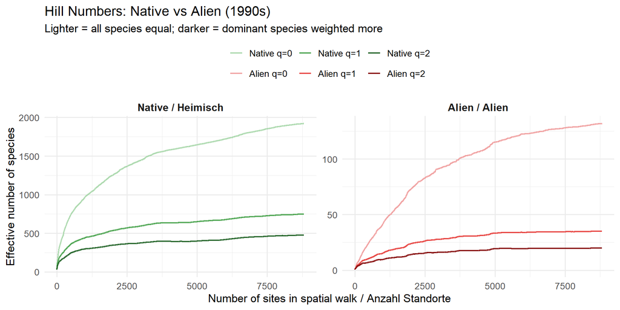

## 6b. Where Does Diversity Live? Alpha vs Beta6b. Wo steckt die Diversität? Alpha vs Beta

Total diversity (**gamma**, $\gamma$) can be split into two components:

- **Alpha** ($\alpha$): the average number of species at a single site
- **Beta** ($\beta$): how many times you need to multiply alpha to reach gamma ($\beta = \gamma / \alpha$)

A high beta means sites are very different from each other; a low beta means every site looks similar. This multiplicative decomposition (Jost 2007) works at each Hill number order $q$.

Die Gesamtdiversität (**Gamma**, $\gamma$) lässt sich in zwei Komponenten zerlegen:

- **Alpha** ($\alpha$): die durchschnittliche Artenzahl an einem einzelnen Standort
- **Beta** ($\beta$): wie oft man Alpha multiplizieren muss, um Gamma zu erreichen ($\beta = \gamma / \alpha$)

Ein hoher Beta-Wert bedeutet, dass sich Standorte stark unterscheiden; ein niedriger, dass alle Standorte ähnlich aussehen.

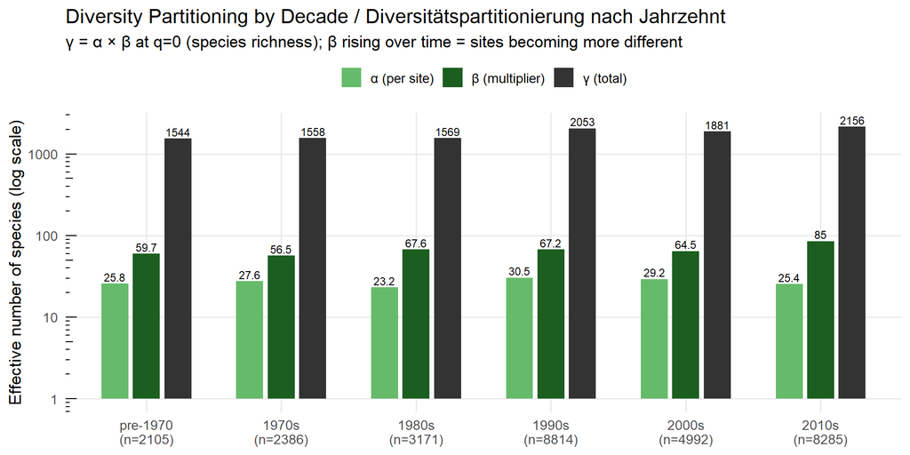

## 6c. Do Aliens Add Evolutionary Novelty?6c. Bringen Aliens evolutionäre Neuheit?

Phylogenetic diversity measures how evolutionarily distant species are from each other. Two complementary metrics capture different aspects:

- **Mean Pairwise Distance (MPD)** tracks the average evolutionary distance between all species pairs. High MPD means the community spans many different plant lineages (broad phylogenetic spread).
- **Mean Nearest Taxon Distance (MNTD)** tracks the average distance to the closest relative for each species. Low MNTD means species tend to cluster in closely related groups (phylogenetic clustering at the tips).

Together, MPD shows the forest and MNTD shows the trees. Comparing native vs alien values reveals whether aliens broaden or narrow the evolutionary portfolio.

Phylogenetische Diversität misst, wie evolutionär entfernt Arten voneinander sind. Zwei komplementäre Metriken erfassen verschiedene Aspekte:

- **Mittlere paarweise Distanz (MPD)** verfolgt die durchschnittliche evolutionäre Distanz zwischen allen Artenpaaren. Hoher MPD bedeutet, dass die Gemeinschaft viele verschiedene Pflanzenlinien umfasst (breite phylogenetische Spreizung).
- **Mittlere nächste Taxon-Distanz (MNTD)** verfolgt die durchschnittliche Distanz zum nächsten Verwandten jeder Art. Niedriger MNTD bedeutet, dass Arten in eng verwandten Gruppen clustern (phylogenetisches Clustering an den Spitzen).

Zusammen zeigt MPD den Wald und MNTD die Bäume. Der Vergleich zwischen heimischen und Alien-Werten zeigt, ob Aliens das evolutionäre Portfolio erweitern oder verengen.

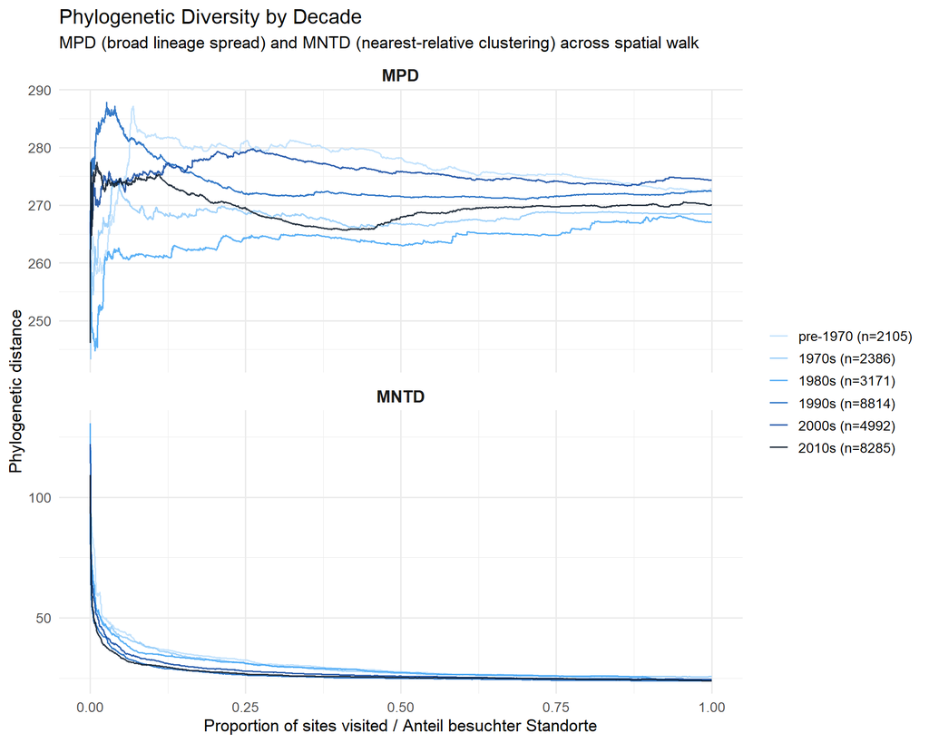

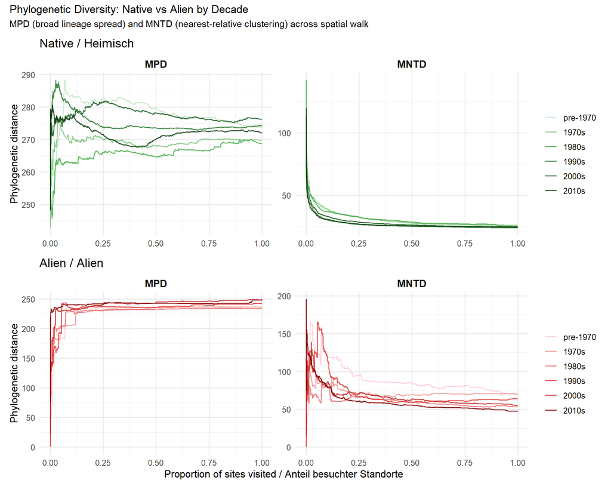

## DiscussionDiskussion

The three analyses converge on a single picture:

**Most of the species we are still “finding” are rare.** The Hill number plots show that the $q=0$ curve (raw richness) keeps climbing long after $q=2$ (dominance-weighted diversity) levels off. The late accumulation adds species that occur at only a few sites. This is true for both natives and aliens, but the effect is proportionally larger for aliens, where a small number of widespread generalists dominate and the remainder are rare, localised newcomers.

**Diversity lives between sites, not within them.** The alpha/beta/gamma partitioning confirms what section 4 already showed: beta diversity (turnover between sites) accounts for the bulk of Austria’s total (gamma) diversity. Any single site captures only a fraction of the national flora.

**Aliens are evolutionary copycats.** Native MPD is consistently higher than alien MPD, meaning the native flora spans a broader range of plant lineages. Aliens are phylogenetically clustered in a few families (Asteraceae, Poaceae, Brassicaceae) that share traits favourable for colonisation: fast growth, high seed output, and disturbance tolerance (Cadotte et al. 2009). The ~88 “missing” alien species from section 3 are therefore likely to be more of the same functional types, not representatives of novel lineages.

**What this means:** counting species overstates the ecological impact of alien arrivals. The invasion debt is real, but the incoming species are unlikely to add much functional or evolutionary novelty to Austrian plant communities.

Die drei Analysen ergeben ein einheitliches Bild:

**Die meisten Arten, die wir noch “finden”, sind selten.** Die Hill-Zahlen-Plots zeigen, dass die $q=0$-Kurve (Artenreichtum) weiter ansteigt, lange nachdem $q=2$ (dominanzgewichtete Diversität) abflacht. Die späte Akkumulation fügt Arten hinzu, die nur an wenigen Standorten vorkommen. Dieser Effekt ist bei Aliens proportional größer: Wenige weitverbreitete Generalisten dominieren, der Rest sind seltene, lokalisierte Neuankömmlinge.

**Die Diversität steckt zwischen den Standorten, nicht innerhalb.** Die Alpha/Beta/Gamma-Partitionierung bestätigt, was Abschnitt 4 bereits zeigte: Beta-Diversität (Turnover zwischen Standorten) macht den Großteil von Österreichs Gesamtdiversität (Gamma) aus.

**Aliens sind evolutionäre Nachahmer.** Der heimische MPD ist durchgehend höher als der Alien-MPD, d.h. die heimische Flora umfasst eine breitere Palette von Pflanzenlinien. Aliens konzentrieren sich phylogenetisch auf wenige Familien (Asteraceae, Poaceae, Brassicaceae), die Merkmale teilen, die Kolonisierung begünstigen: schnelles Wachstum, hohe Samenproduktion und Störungstoleranz (Cadotte et al. 2009). Die ~88 “fehlenden” Alien-Arten aus Abschnitt 3 dürften daher eher dieselben Funktionstypen sein, nicht Vertreter neuer Linien.

**Was das bedeutet:** Artenzählung allein überschätzt die ökologische Wirkung von Alien-Ankünften. Die Invasionsschuld ist real, aber die kommenden Arten werden wahrscheinlich wenig funktionelle oder evolutionäre Neuheit zu Österreichs Pflanzengemeinschaften beitragen.

# SynthesisSynthese

**1. Sampling & raw richness.** The hotspot maps reflect where data was collected and what observed richness looks like. Natives peak in topographically complex pre-Alpine zones; aliens concentrate around human infrastructure in the lowlands. These patterns partly reflect sampling effort.

**2. Accumulation curves.** Aliens have higher spatial beta diversity than natives; you need to sample more area to find the same proportion of species. This confirms quantitatively what the maps show.

**3. Incomplete sampling.** We know ~94% of the native flora but only ~79% of the alien flora. The gap represents invasion debt: species already present but not yet found, or species still arriving. The per-hexagon extrapolation maps show where in Austria that debt is concentrated.

**6. What kind of diversity?** Rare species drive the tail of the accumulation curve, beta diversity dominates gamma, and aliens are phylogenetically clustered in a few families. The invasion debt is real in numbers, but the incoming species are unlikely to add much evolutionary novelty.

These results show that **spatial species accumulation curves** are more than a sampling tool. They connect biogeography, invasion ecology, and conservation planning. The `spacc` package makes this type of analysis available for any georeferenced community dataset.

**1. Beprobung & beobachteter Reichtum.** Die Hotspot-Karten zeigen, wo beprobt wurde und wie der beobachtete Artenreichtum aussieht. Einheimische erreichen ihren Höhepunkt in den topografisch komplexen Voralpen; Aliens konzentrieren sich um menschliche Infrastruktur im Tiefland. Diese Muster spiegeln teilweise den Beprobungsaufwand wider.

**2. Räumliche Akkumulation.** Die normalisierten Kurven zeigen, dass Aliens eine höhere räumliche Beta-Diversität haben als Einheimische.

**3. Unvollständige Beprobung.** Die Extrapolation zeigt, dass wir nur ~79% der Alien-Flora kennen gegenüber ~94% der Einheimischen. Die Hexagon-Karten lokalisieren, wo diese Schuld konzentriert ist.

**6. Welche Art von Diversität?** Seltene Arten treiben das Ende der Akkumulationskurve, Beta-Diversität dominiert Gamma, und Aliens konzentrieren sich phylogenetisch auf wenige Familien. Die Invasionsschuld ist zahlenmäßig real, aber die kommenden Arten dürften wenig evolutionäre Neuheit bringen.

Zusammen zeigen diese Ergebnisse, dass **räumliche Artenakkumulationskurven** weit mehr als eine Beprobungsmethode sind.

## ReferencesLiteraturverzeichnis

- Baselga, A. (2010). Partitioning the turnover and nestedness components of beta diversity. *Global Ecology and Biogeography*, 19, 134–143.
- Cadotte, M.W. et al. (2009). Using phylogenetic, functional and trait diversity to understand patterns of plant community productivity. *PLoS ONE*, 4, e5695.
- Chao, A. & Jost, L. (2012). Coverage-based rarefaction and extrapolation. *Methods in Ecology and Evolution*, 3, 217–226.
- Chytry, M. et al. (2008). Habitat invasions by alien plants: a quantitative comparison among Mediterranean, subcontinental and oceanic regions of Europe. *Journal of Applied Ecology*, 45, 448–458.
- Chytry, M. et al. (2009). European map of alien plant invasions based on the quantitative assessment across habitats. *Diversity and Distributions*, 15, 98–107.
- Chytry, M. et al. (2016). European Vegetation Archive (EVA): an integrated database of European vegetation plots. *Applied Vegetation Science*, 19, 173–180.
- Colwell, R.K. & Coddington, J.A. (1994). Estimating terrestrial biodiversity through extrapolation. *Philosophical Transactions of the Royal Society B*, 345, 101–118.
- Davis, M.A. et al. (2000). Fluctuating resources in plant communities: a general theory of invasibility. *Journal of Ecology*, 88, 528–534.
- Essl, F. et al. (2011). Socioeconomic legacy yields an invasion debt. *Proceedings of the National Academy of Sciences*, 108, 203–207.
- Grabherr, G. et al. (2003). *Die Pflanzengesellschaften Osterreichs*. Gustav Fischer Verlag.
- Hill, M.O. (1973). Diversity and evenness: a unifying notation and its consequences. *Ecology*, 54, 427–432.
- Jost, L. (2006). Entropy and diversity. *Oikos*, 113, 363–375.
- Kier, G. et al. (2009). A global assessment of endemism and species richness across island and mainland regions. *PNAS*, 106, 9322–9327.
- Lockwood, J.L. et al. (2005). The role of propagule pressure in explaining species invasions. *Trends in Ecology & Evolution*, 20, 223–228.
- Partel, M. et al. (2011). Dark diversity: shedding light on absent species. *Trends in Ecology & Evolution*, 26, 596–600.
- Pysek, P. et al. (2010). Disentangling the role of environmental and human pressures on biological invasions across Europe. *PNAS*, 107, 12157–12162.
- Rahbek, C. (1995). The elevational gradient of species richness: a uniform pattern? *Ecography*, 18, 200–205.
- Seebens, H. et al. (2017). No saturation in the accumulation of alien species worldwide. *Nature Communications*, 8, 14435.
- Socolar, J.B. et al. (2016). How should beta-diversity inform biodiversity conservation? *Trends in Ecology & Evolution*, 31, 67–80.
- Tjorve, E. (2010). How to resolve the SLOSS debate: lessons from species-diversity models. *Journal of Theoretical Biology*, 264, 604–612.
- Wilson, J.R.U. et al. (2007). Residence time and potential range: crucial considerations in modelling plant invasions. *Diversity and Distributions*, 13, 11–22.